# Tutorial_scRNAseqAnalysis

Jeong-Eun Lee and Melanie Sarfert

#### Required packages

Please install the following packages before you start this tutorial: here, Seurat

- **here**: https://cran.r-project.org/web/packages/here/index.html
- **Seurat**: https://satijalab.org/seurat/articles/install.html

#### Tutorial files

Please download a [GitHub repository](https://github.com/hermes1130/GeGe_tutorial) for both of tutorial days

# Short background for the dataset

For this tutorial, we will be analyzing the a dataset of scRNA-seq (10x Genomics) to profile cell composition across a time course of human/chimpanzee organoid development from pluripotency to four months using embryonic stem cells (H9) and iPSC (409b2) lines and chimpanzee iPSC (Sandra/SandraA) lines ([Kanton et al. 2019](https://www.nature.com/articles/s41586-019-1654-9)). This means, the dataset contains multiple readcount metrics per cells including the timepoint

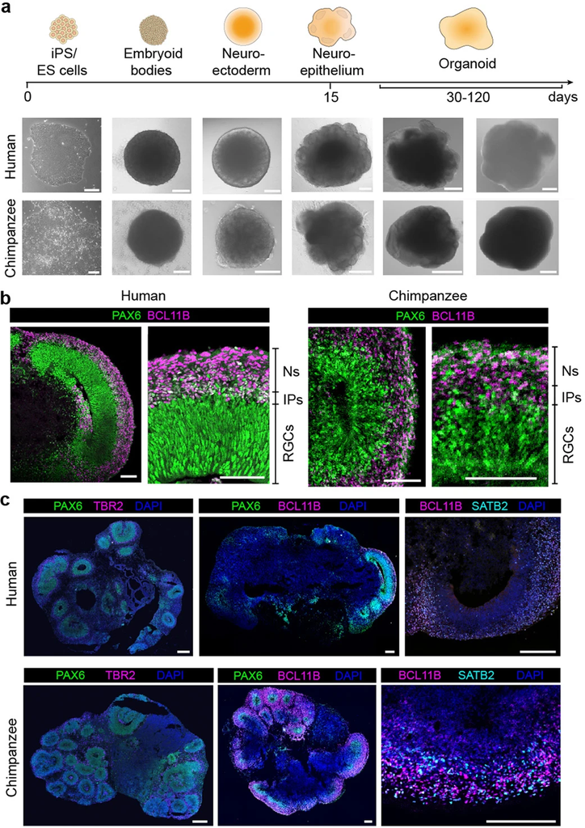

Differentiation of human and chimpanzee cerebral organoids.

# Setup the Seurat Object

Load the library here and Seurat package

```r
library("here")
library("Seurat")
```

We start by reading in the data. The readRDS() function reads Large Seurat files in the output of the Seurat pipeline, returning a S4 SeuratObject. The values in assays represent the multiple read count tables for each feature (i.e. gene; row) that are detected in each cell (column). For example, hu[[“RNA”]]@counts

Let’s import the rds files using here

```r
hu <- readRDS("files/timecourse_human_singlecells_GRCh38.rds")
hu <- subset(x = hu, downsample = 100, invert = TRUE)
#100 cells in each cell type and remove idents with invert
```

```r
hu <- readRDS("files/Tutorial_tc_human_integ_RNAassay.rds")
hu
```

```
## An object of class Seurat
## 33694 features across 2000 samples within 1 assay
## Active assay: RNA (33694 features, 4506 variable features)
##  2 dimensional reductions calculated: pca, tsne
```

```r
ch <- readRDS("files/Tutorial_tc_chimp_integ_RNAassay.rds")
ch
```

```
## An object of class Seurat
## 32856 features across 2499 samples within 1 assay
## Active assay: RNA (32856 features, 3680 variable features)
##  2 dimensional reductions calculated: pca, tsne
```

Explore the Large Seurat objects

```r
head(hu@meta.data, 5)
```

|  | nCount_RNA | nFeature_RNA | percent.mito | species | stage | stage_group | line | sample | barcode | human.ratio | human.raw | chimp.ratio | chimp.raw | ClusterNames_init | Cluster |
| --- | --- | --- | --- | --- | --- | --- | --- | --- | --- | --- | --- | --- | --- | --- | --- |
| EC00044 | 13148 | 3353 | 0.07506845 | human | iPSCs | iPSCs | H9 | H9_iPSCs | AAAGATGTCACCCGAG | 0.9731237 | 15352 | 0.02687627 | 424 | 0 | stem cells 1 |
| EC00060 | 11535 | 3075 | 0.04924144 | human | iPSCs | iPSCs | H9 | H9_iPSCs | AAAGCAAGTGCCTGCA | 0.9782801 | 11035 | 0.02171986 | 245 | 0 | stem cells 1 |
| EC00075 | 12357 | 3022 | 0.02354941 | human | iPSCs | iPSCs | h409B2 | h409B2_iPSCs | AAAGTAGGTCACCTAA | 0.9768264 | 9400 | 0.02317365 | 223 | 0 | stem cells 1 |
| EC00162 | 20107 | 4454 | 0.04739643 | human | iPSCs | iPSCs | h409B2 | h409B2_iPSCs | AACTCTTAGTGACTCT | 0.9796116 | 19267 | 0.02038845 | 401 | 13 | stem cells 1 |
| EC00191 | 17782 | 4222 | 0.04926330 | human | iPSCs | iPSCs | h409B2 | h409B2_iPSCs | AACTTTCCAAGCCTAT | 0.9807219 | 17551 | 0.01927805 | 345 | 0 | stem cells 1 |

```r
hu[["RNA"]]@counts[1:10, 1:40]
```

```
## 10 x 40 sparse Matrix of class "dgCMatrix"
```

```
##   [[ suppressing 40 column names 'EC00044', 'EC00060', 'EC00075' ... ]]
```

```
##
## RP11-34P13.3  . . . . . . . . . . . . . . . . . . . . . . . . . . . . . . . . .
## FAM138A       . . . . . . . . . . . . . . . . . . . . . . . . . . . . . . . . .
## OR4F5         . . . . . . . . . . . . . . . . . . . . . . . . . . . . . . . . .
## RP11-34P13.7  . . . . . . . . . . . . . . . . . . . . . . . . . . . . . . . . .
## RP11-34P13.8  . . . . . . . . . . . . . . . . . . . . . . . . . . . . . . . . .
## RP11-34P13.14 . . . . . . . . . . . . . . . . . . . . . . . . . . . . . . . . .
## RP11-34P13.9  . . . . . . . . . . . . . . . . . . . . . . . . . . . . . . . . .
## FO538757.3    . . . . . . . . . . . . . . . . . . . . . . . . . . . . . . . . .
## FO538757.2    1 . . . . . . 1 . . . 1 . . 1 . . 1 1 1 . . 1 . . . . . . . . . .
## AP006222.2    . 2 . . . 1 . . . . . . . 1 . . . 1 . . . . . . . . . . . . 1 1 .
##
## RP11-34P13.3  . . . . . . .
## FAM138A       . . . . . . .
## OR4F5         . . . . . . .
## RP11-34P13.7  . . . . . . .
## RP11-34P13.8  . . . . . . .
## RP11-34P13.14 . . . . . . .
## RP11-34P13.9  . . . . . . .
## FO538757.3    . . . . . . .
## FO538757.2    . 1 . 1 1 . .
## AP006222.2    1 1 . . 1 . .
```

```r
head(ch@meta.data, 5)
```

|  | species | stage | stage_group | line | sample | barcode | orig.ident | percent.mito | res.0.6 | pseudogroup | nCount_RNA | nFeature_RNA | cl |
| --- | --- | --- | --- | --- | --- | --- | --- | --- | --- | --- | --- | --- | --- |
| EC00002 | chimp | iPSCs | iPSCs | SandraA | SandraA_iPSCs | AAACCTGAGTGCCATT | chimp-dev lineage | 0.0000000000 | 23 | SandraA_iPSCs_24 | 3112 | 1023 | stem cells 2 |
| EC00070 | chimp | iPSCs | iPSCs | SandraA | SandraA_iPSCs | AAAGTAGCACGTCTCT | chimp-dev lineage | 0.0002724053 | 23 | SandraA_iPSCs_24 | 3671 | 1325 | stem cells 2 |
| EC00096 | chimp | iPSCs | iPSCs | SandraA | SandraA_iPSCs | AACCATGAGTCCATAC | chimp-dev lineage | 0.0000000000 | 23 | SandraA_iPSCs_24 | 4600 | 1510 | stem cells 2 |
| EC00136 | chimp | iPSCs | iPSCs | SandraA | SandraA_iPSCs | AACTCAGGTACACCGC | chimp-dev lineage | 0.0000000000 | 23 | SandraA_iPSCs_24 | 3143 | 1207 | stem cells 2 |
| EC00148 | chimp | iPSCs | iPSCs | SandraA | SandraA_iPSCs | AACTCCCCAAGGACTG | chimp-dev lineage | 0.0000000000 | 23 | SandraA_iPSCs_24 | 4687 | 1405 | stem cells 2 |

```r
ch[["RNA"]]@counts[1:10, 1:40]
```

```
## 10 x 40 sparse Matrix of class "dgCMatrix"
```

```
##   [[ suppressing 40 column names 'EC00002', 'EC00070', 'EC00096' ... ]]
```

```
##
## MIR1302-2HG . . . . . . . . . . . . . . . . . . . . . . . . . . . . . . . . . .
## FAM138A     . . . . . . . . . . . . . . . . . . . . . . . . . . . . . . . . . .
## OR4F5       . . . . . . . . . . . . . . . . . . . . . . . . . . . . . . . . . .
## AL627309.1  . . . . . . . . . . . . . . . . . . . . . . . . . . . . . . . . . .
## AL627309.3  . . . . . . . . . . . . . . . . . . . . . . . . . . . . . . . . . .
## AL627309.2  . . . . . . . . . . . . . . . . . . . . . . . . . . . . . . . . . .
## AL627309.4  . . . . . . . . . . . . . . . . . . . . . . . . . . . . . . . . . .
## AL732372.1  . . . . . . . . . . . . . . . . . . . . . . . . . . . . . . . . . .
## OR4F29      . . . . . . . . . . . . . . . . . . . . . . . . . . . . . . . . . .
## AC114498.1  . . . . . . . . . . . . . . . . . . . . . . . . . . . . . . . . . .
##
## MIR1302-2HG . . . . . .
## FAM138A     . . . . . .
## OR4F5       . . . . . .
## AL627309.1  . . . . . .
## AL627309.3  . . . . . .
## AL627309.2  . . . . . .
## AL627309.4  . . . . . .
## AL732372.1  . . . . . .
## OR4F29      . . . . . .
## AC114498.1  . . . . . .
```

As you see, those rds files are already pre-processed, for instance cell lines are already integrated and the linear/non-linear dimensional reduction has already been performed. We’ll now split the datasets, so we can practice the whole process to learn how to run a standard Seurat clustering pipeline.

Split the dataset into a list of two seurat objects by cell line.

```r
Split_hu <- SplitObject(hu, split.by = "line")
Split_hu
```

```
## $H9
## An object of class Seurat
## 33694 features across 971 samples within 1 assay
## Active assay: RNA (33694 features, 4506 variable features)
##  2 dimensional reductions calculated: pca, tsne
##
## $h409B2
## An object of class Seurat
## 33694 features across 1029 samples within 1 assay
## Active assay: RNA (33694 features, 4506 variable features)
##  2 dimensional reductions calculated: pca, tsne
```

```r
Split_ch <- SplitObject(ch, split.by = "line")
Split_ch
```

```
## $SandraA
## An object of class Seurat
## 32856 features across 559 samples within 1 assay
## Active assay: RNA (32856 features, 3680 variable features)
##  2 dimensional reductions calculated: pca, tsne
##
## $Sandra
## An object of class Seurat
## 32856 features across 1940 samples within 1 assay
## Active assay: RNA (32856 features, 3680 variable features)
##  2 dimensional reductions calculated: pca, tsne
```

After spliting cell lines from the dataset, the next step is to normalize the data. By default, we employ a global-scaling normalization method “LogNormalize” that normalizes the feature expression measurements for each cell by the total expression, multiplies this by a scale factor (10,000 by default), and log-transforms the result. Normalized values are stored in NorFea_hu$H9[[“RNA”]]@data.

We next calculate a subset of features that exhibit high cell-to-cell variation in the dataset (i.e, they are highly expressed in some cells, and lowly expressed in others). Focusing on these genes in downstream analysis helps to highlight biological signal in single-cell datasets. This is implemented in the FindVariableFeatures() function. By default, we return 2,000 features per dataset. These will be used in downstream analysis, like PCA.

The normalization and identification of variable features for each dataset independently will be done in one commmend using laaply().

```r
NorFea_hu <- lapply(X = Split_hu, FUN = function(x) {
  x <- NormalizeData(x)
  x <- FindVariableFeatures(x, selection.method = "vst", nfeatures = 2000)
})
NorFea_hu
```

```
## $H9
## An object of class Seurat
## 33694 features across 971 samples within 1 assay
## Active assay: RNA (33694 features, 2000 variable features)
##  2 dimensional reductions calculated: pca, tsne
##
## $h409B2
## An object of class Seurat
## 33694 features across 1029 samples within 1 assay
## Active assay: RNA (33694 features, 2000 variable features)
##  2 dimensional reductions calculated: pca, tsne
```

```r
NorFea_hu$H9[["RNA"]]@data[1:10, 1:40]
```

```
## 10 x 40 sparse Matrix of class "dgCMatrix"
```

```
##   [[ suppressing 40 column names 'EC00044', 'EC00060', 'EC00296' ... ]]
```

```
##
## RP11-34P13.3  .         .        .         . . . .         .         .
## FAM138A       .         .        .         . . . .         .         .
## OR4F5         .         .        .         . . . .         .         .
## RP11-34P13.7  .         .        .         . . . .         .         .
## RP11-34P13.8  .         .        .         . . . .         .         .
## RP11-34P13.14 .         .        .         . . . .         .         .
## RP11-34P13.9  .         .        .         . . . .         .         .
## FO538757.3    .         .        .         . . . .         .         .
## FO538757.2    0.5656387 .        .         . . . 0.3090438 0.4445882 .
## AP006222.2    .         1.005712 0.4071387 . . . .         .         .
##
## RP11-34P13.3  .         .         . . .         . . . . .         .         .
## FAM138A       .         .         . . .         . . . . .         .         .
## OR4F5         .         .         . . .         . . . . .         .         .
## RP11-34P13.7  .         .         . . .         . . . . .         .         .
## RP11-34P13.8  .         .         . . .         . . . . .         .         .
## RP11-34P13.14 .         .         . . .         . . . . .         .         .
## RP11-34P13.9  .         .         . . .         . . . . .         .         .
## FO538757.3    .         .         . . .         . . . . .         .         .
## FO538757.2    0.4108021 0.4861095 . . 0.3577626 . . . . .         .         .
## AP006222.2    0.4108021 .         . . .         . . . . 0.6489736 0.4776818 .
##
## RP11-34P13.3  .         . . .         . .         . .         .         . .
## FAM138A       .         . . .         . .         . .         .         . .
## OR4F5         .         . . .         . .         . .         .         . .
## RP11-34P13.7  .         . . .         . .         . .         .         . .
## RP11-34P13.8  .         . . .         . .         . .         .         . .
## RP11-34P13.14 .         . . .         . .         . .         .         . .
## RP11-34P13.9  .         . . .         . .         . .         .         . .
## FO538757.3    .         . . .         . .         . .         .         . .
## FO538757.2    0.5001261 . . 0.4881182 . .         . 0.2898991 .         . .
## AP006222.2    0.5001261 . . 0.4881182 . 0.7170238 . 0.2898991 0.3503035 . .
##
## RP11-34P13.3  .         . . . . . .         .
## FAM138A       .         . . . . . .         .
## OR4F5         .         . . . . . .         .
## RP11-34P13.7  .         . . . . . .         .
## RP11-34P13.8  .         . . . . . .         .
## RP11-34P13.14 .         . . . . . .         .
## RP11-34P13.9  .         . . . . . .         .
## FO538757.3    .         . . . . . .         .
## FO538757.2    0.3520979 . . . . . 0.5147495 .
## AP006222.2    0.3520979 . . . . . .         .
```

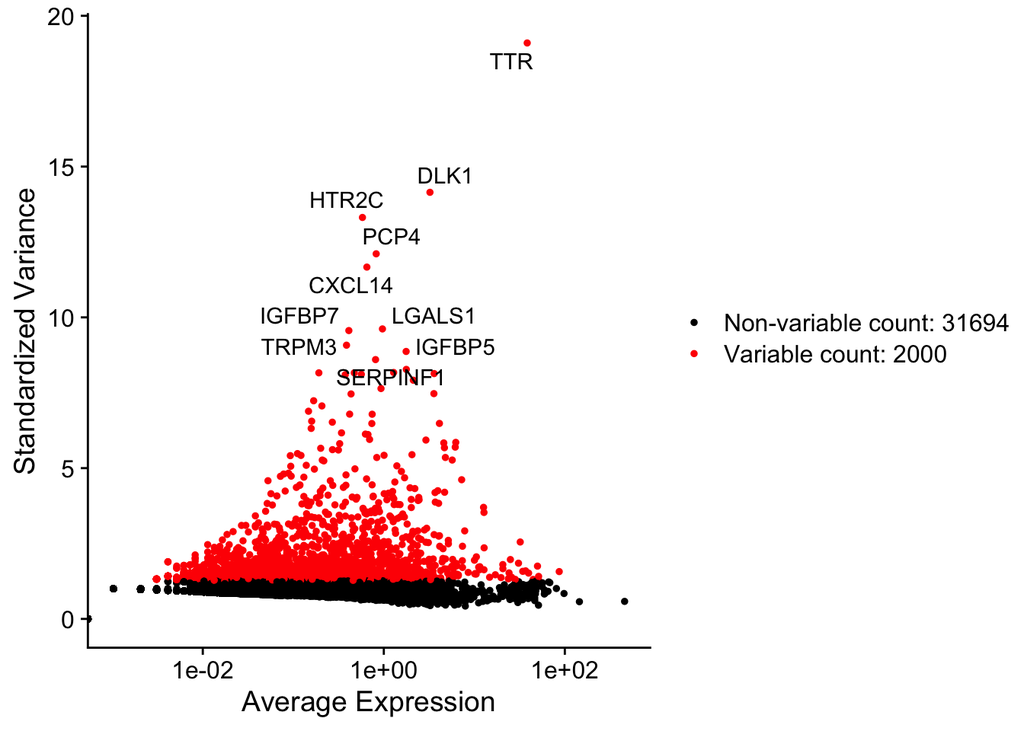

```r
VFP_H9 <- VariableFeaturePlot(NorFea_hu$H9)
VFP_H9 <- LabelPoints(plot = VFP_H9, points = head(VariableFeatures(NorFea_hu$H9), 10), repel = TRUE, xnudge = 0, ynudge = 0)
VFP_h209B2 <- VariableFeaturePlot(NorFea_hu$h409B2)
VFP_h209B2 <- LabelPoints(plot = VFP_h209B2, points = head(VariableFeatures(NorFea_hu$h409B2), 10), repel = TRUE, xnudge = 0, ynudge = 0)
VFP_H9
```

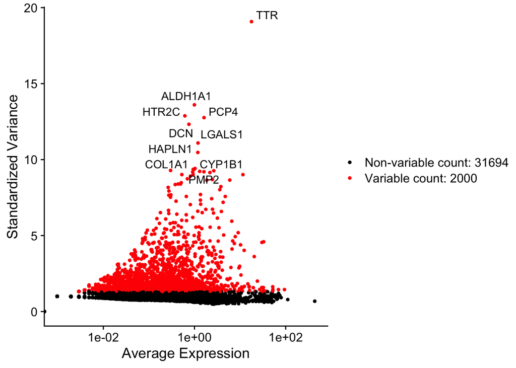

```r
VFP_h209B2
```

```r
NorFea_ch <- lapply(X = Split_ch, FUN = function(x) {
  x <- NormalizeData(x)
  x <- FindVariableFeatures(x, selection.method = "vst", nfeatures = 2000)
})
NorFea_ch
```

```
## $SandraA
## An object of class Seurat
## 32856 features across 559 samples within 1 assay
## Active assay: RNA (32856 features, 2000 variable features)
##  2 dimensional reductions calculated: pca, tsne
##
## $Sandra
## An object of class Seurat
## 32856 features across 1940 samples within 1 assay
## Active assay: RNA (32856 features, 2000 variable features)
##  2 dimensional reductions calculated: pca, tsne
```

```r
NorFea_ch$SandraA[["RNA"]]@data[1:10, 1:40]
```

```
## 10 x 40 sparse Matrix of class "dgCMatrix"
```

```
##   [[ suppressing 40 column names 'EC00002', 'EC00070', 'EC00096' ... ]]
```

```
##
## MIR1302-2HG . . . . . . . . . . . . . . . . . . . . . . . . . . . . . . . . . .
## FAM138A     . . . . . . . . . . . . . . . . . . . . . . . . . . . . . . . . . .
## OR4F5       . . . . . . . . . . . . . . . . . . . . . . . . . . . . . . . . . .
## AL627309.1  . . . . . . . . . . . . . . . . . . . . . . . . . . . . . . . . . .
## AL627309.3  . . . . . . . . . . . . . . . . . . . . . . . . . . . . . . . . . .
## AL627309.2  . . . . . . . . . . . . . . . . . . . . . . . . . . . . . . . . . .
## AL627309.4  . . . . . . . . . . . . . . . . . . . . . . . . . . . . . . . . . .
## AL732372.1  . . . . . . . . . . . . . . . . . . . . . . . . . . . . . . . . . .
## OR4F29      . . . . . . . . . . . . . . . . . . . . . . . . . . . . . . . . . .
## AC114498.1  . . . . . . . . . . . . . . . . . . . . . . . . . . . . . . . . . .
##
## MIR1302-2HG . . . . . .
## FAM138A     . . . . . .
## OR4F5       . . . . . .
## AL627309.1  . . . . . .
## AL627309.3  . . . . . .
## AL627309.2  . . . . . .
## AL627309.4  . . . . . .
## AL732372.1  . . . . . .
## OR4F29      . . . . . .
## AC114498.1  . . . . . .
```

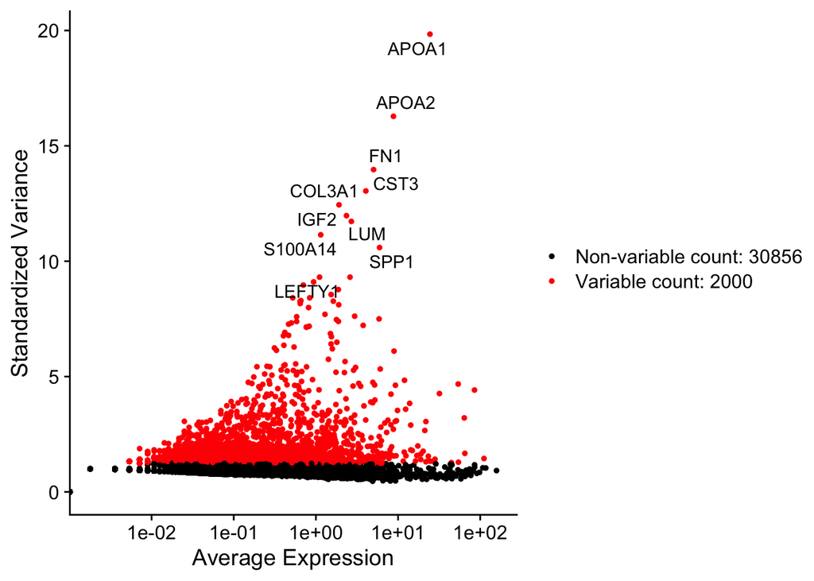

```r
VFP_SA <- VariableFeaturePlot(NorFea_ch$SandraA)
VFP_SA <- LabelPoints(plot = VFP_SA, points = head(VariableFeatures(NorFea_ch$SandraA), 10), repel = TRUE, xnudge = 0, ynudge = 0)
VFP_S <- VariableFeaturePlot(NorFea_ch$Sandra)
VFP_S <- LabelPoints(plot = VFP_S, points = head(VariableFeatures(NorFea_ch$Sandra), 10), repel = TRUE, xnudge = 0, ynudge = 0)
VFP_SA
```

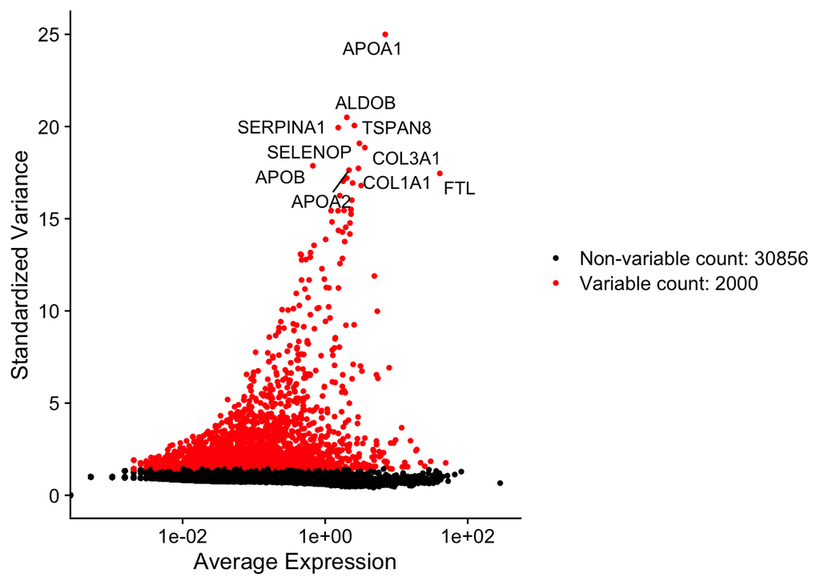

```r
VFP_S
```

Now, we see that the number of variable features has been changed to 2000 in each cell line. We will now select features that are repeatedly variable across datasets for integration.

```r
features_h <- SelectIntegrationFeatures(object.list = NorFea_hu)
head(features_h, n = 10)
```

```
##  [1] "TTR"    "HTR2C"  "PCP4"   "LGALS1" "DLK1"   "CXCL14" "COL1A1" "COL3A1"
##  [9] "IGFBP7" "PTN"
```

```r
features_c <- SelectIntegrationFeatures(object.list = NorFea_ch)
head(features_c, n = 10)
```

```
##  [1] "APOA1"  "APOA2"  "COL3A1" "APOB"   "IGF2"   "TTR"    "APOA4"  "COL1A1"
##  [9] "LUM"    "DLK1"
```

# Perform integration

We then identify anchors using the FindIntegrationAnchors() function, which takes a list of Seurat objects as input, and use these anchors to integrate the two datasets together with IntegrateData().

```r
anchors_hu <- FindIntegrationAnchors(object.list = NorFea_hu, anchor.features = features_h)
```

```
## Scaling features for provided objects
```

```
## Finding all pairwise anchors
```

```
## Running CCA
```

```
## Merging objects
```

```
## Finding neighborhoods
```

```
## Finding anchors
```

```
##  Found 2423 anchors
```

```
## Filtering anchors
```

```
##  Retained 2257 anchors
```

```r
anchors_hu
```

```
## An AnchorSet object containing 4514 anchors between 2 Seurat objects
##  This can be used as input to IntegrateData.
```

```r
anchors_ch <- FindIntegrationAnchors(object.list = NorFea_ch, anchor.features = features_c)
```

```
## Scaling features for provided objects
```

```
## Finding all pairwise anchors
```

```
## Running CCA
```

```
## Merging objects
```

```
## Finding neighborhoods
```

```
## Finding anchors
```

```
##  Found 2377 anchors
```

```
## Filtering anchors
```

```
##  Retained 857 anchors
```

```r
anchors_ch
```

```
## An AnchorSet object containing 1714 anchors between 2 Seurat objects
##  This can be used as input to IntegrateData.
```

We then pass these anchors to the IntegrateData() function, which returns a Seurat object.

The returned object will contain a new Assay, which holds an integrated (or ‘batch-corrected’) expression matrix for all cells, enabling them to be jointly analyzed.

```r
hu_integ <- IntegrateData(anchorset = anchors_hu)
```

```
## Merging dataset 1 into 2
```

```
## Extracting anchors for merged samples
```

```
## Finding integration vectors
```

```
## Finding integration vector weights
```

```
## Integrating data
```

```r
hu_integ
```

```
## An object of class Seurat
## 35694 features across 2000 samples within 2 assays
## Active assay: integrated (2000 features, 2000 variable features)
##  1 other assay present: RNA
```

```r
ch_integ <- IntegrateData(anchorset = anchors_ch)
```

```
## Merging dataset 1 into 2
```

```
## Extracting anchors for merged samples
```

```
## Finding integration vectors
```

```
## Finding integration vector weights
```

```
## Integrating data
```

```r
ch_integ
```

```
## An object of class Seurat
## 34856 features across 2499 samples within 2 assays
## Active assay: integrated (2000 features, 2000 variable features)
##  1 other assay present: RNA
```

Now, the number of features has also been changed to 2000 in each object and the active assay is set to ‘integrated’. The original unmodified data still resides in the ‘RNA’ assay.

# Scaling the data

```r
hu_integ <- ScaleData(hu_integ, verbose = FALSE)
ch_integ <- ScaleData(ch_integ, verbose = FALSE)
```

# Perform linear dimensional reduction

Next, we perform PCA on the scaled data. By default, only the previously determined variable features are used as input and we define the number of PCs to compute and store (50 by default).

```r
hu_integ <- RunPCA(hu_integ, verbose = FALSE)
hu_integ
```

```
## An object of class Seurat
## 35694 features across 2000 samples within 2 assays
## Active assay: integrated (2000 features, 2000 variable features)
##  1 other assay present: RNA
##  1 dimensional reduction calculated: pca
```

```r
ch_integ <- RunPCA(ch_integ, verbose = FALSE)
ch_integ
```

```
## An object of class Seurat
## 34856 features across 2499 samples within 2 assays
## Active assay: integrated (2000 features, 2000 variable features)
##  1 other assay present: RNA
##  1 dimensional reduction calculated: pca
```

Now, the Seurat object contains one dimensional reduction: pca.

# Determine the dimensionality of the dataset

To overcome the extensive technical noise in any single feature for scRNA-seq data, Seurat clusters cells based on their PCA scores, with each PC essentially representing a ‘metafeature’ that combines information across a correlated feature set. The top principal components therefore represent a robust compression of the dataset. However, how many components should we choose to include? To answer this question, we’ll consider three approaches below.

### First approach

Seurat provides several useful ways of visualizing both cells and features that define the PCA, including VizDimReduction(), DimPlot(), and DimHeatmap(). In particular **DimHeatmap()** allows for easy exploration of the primary sources of heterogeneity in a dataset, and can be useful when trying to decide which PCs to include for further downstream analyses.

For instance, let’s visualize the first and last PC.

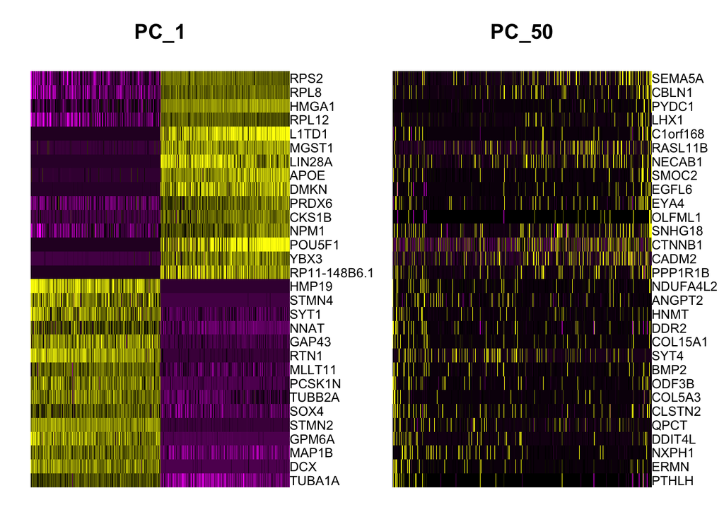

```r
DimHeatmap(hu_integ, dims = c(1,50), cells = 500, balanced = TRUE)
```

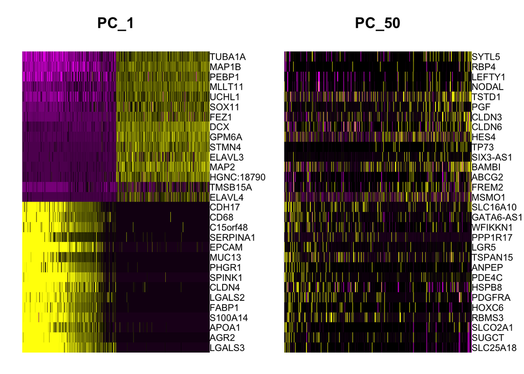

```r
DimHeatmap(ch_integ, dims = c(1,50), cells = 500, balanced = TRUE)
```

The first PC shows a clear heterogeneity, while the last one doesn’t. The cutoff should be somewhere between PC1 and PC50 (wink wink ;))

### Second approach

As next approach, we randomly permute a subset of the data (1% by default) and rerun PCA, constructing a ‘null distribution’ of feature scores, and repeat this procedure. We identify ‘significant’ PCs as those who have a strong enrichment of low p-value features. This implements a statistical test based on a random null model, but is time-consuming for large datasets.

Determine stastistical significance of PCA scores using JackStraw(), compute JackStraw scores significance using ScoreJAckStraw. JackStrawPlot() function provides a visualization tool for comparing the distribution of p-values for each PC with a uniform distribution (dashed line). ‘Significant’ PCs will show a strong enrichment of features with low p-values (solid curve above the dashed line).

This takes up to 5 min

```r
JS_hu <- JackStraw(hu_integ, dims = 50, num.replicate = 100)
JS_hu <- ScoreJackStraw(JS_hu, dims = 1:50)
JackStrawPlot(JS_hu, dims = c(1, 50))

JS_ch <- JackStraw(ch_integ, dims = 50, num.replicate = 100)
JS_ch <- ScoreJackStraw(JS_ch, dims = 1:50)
JackStrawPlot(JS_ch, dims = c(1, 50))
```

[output not shown]